# Moderator analyses

## Run meta-regression

```r
# Cannot save temp file on GitHub due to size
# so instead can download it from the OSF
# If you want to re-estimate the models, set this to false
download_file <- TRUE

if (file.exists("data/imp_meta_reg_mods.qs")) {
  imputed_mods <- qs::qread("data/imp_meta_reg_mods.qs")
} else {
  if (download_file == TRUE) {
    download.OSF.file("49gzu", file_name = "data/imp_meta_reg_mods.qs")
    imputed_mods <- try(qs::qread("data/imp_meta_reg_mods.qs"), silent = TRUE)
    if (inherits(imputed_mods, "try-error")) {
      message("Could not load imputed models - will re-impute.")
    }
  }

  if (inherits(imputed_mods, "try-error") | !download_file) {

  if (!exists("imp")) stop("Imputation object (imp) not found - run/load imputation first.")
  job::job("Impute meta-regression" = {
    imp_datasets <- complete(imp, "all")
    with_progress({
      p <- progressor(steps = length(imp_datasets), label = "Imputing meta-regression models")
      imputed_mods <- map(imp_datasets, \(data) {
        p()
        try({
          with(data, {
            V <- impute_covariance_matrix(
              vi = var_adj,
              cluster = articlestudy,
              r = rho
            )

            complexity <- factor(complexity, ordered = FALSE) %>% relevel(ref = "high")
            interdep <- factor(interdep, ordered = FALSE) %>% relevel(ref = "high")
            longevity <- factor(longevity, ordered = FALSE) %>% relevel(ref = "stable")
            art_focus <- factor(art_focus) %>% relevel(ref = "focal H")
            meas_type <- factor(meas_type) %>% relevel(ref = "Variety")
            rater <- factor(rater) %>% relevel(ref = "Objective")
            design <- factor(design) %>% relevel(ref = "Observational")

            mod <- rma.mv(
              r_adj ~ year_merged + complexity + interdep + collectivism +
                longevity + meas_type + rater + design + art_focus,
              V = V,
              random = ~ 1 | articlestudy / effect_id,
              test = "t",
              dfs = "contain",
              sparse = TRUE
            )

            mod_interact <- rma.mv(
              r_adj ~ domain * year_merged + domain * complexity + domain * interdep + domain * collectivism +
                domain * longevity + domain * meas_type + domain * rater + domain * design + domain * art_focus,
              V = V,
              random = ~ 1 | articlestudy / effect_id,
              test = "t",
              dfs = "contain",
              sparse = TRUE
            )

            list(mod = mod, mod_interact = mod_interact)
          })
        })
      })
      imputed_mods %>% qs::qsave("data/imp_meta_reg_mods.qs")
      job::export(NULL)
    })
  })
 message("Models will be imputed now in background job - rerun this chunk afterwards to load them.")
}}
```

```r
# Pool results
## Remove failed convergence
m <- length(imputed_mods)
imputed_mods <- imputed_mods %>% discard(\(x) inherits(x, "try-error"))
message("Excluded ", m - length(imputed_mods), " models due to convergence issues.")
```

```
## Excluded 2 models due to convergence issues.
```

```r
coefs_across <- map(imputed_mods, "mod") %>% pool_robust()
coefs_domains <- map(imputed_mods, "mod_interact") %>% pool_robust()

cat_moderators <- c("complexity", "interdep", "longevity", "meas_type", "rater", "design", "art_focus")
cont_moderators <- c("year_merged", "collectivism", "power_distance")

# Run Wald tests

if (file.exists("data/cat_domain_wald_test_multiple.rds")) {
  cat_interaction_tests <- read_rds("data/cat_domain_wald_test_multiple.rds")
} else {
  cat_moderators_regex <- c(
    paste0("^", cat_moderators),
    paste0("Cognitive:", cat_moderators),
    paste0("Job-related:", cat_moderators)
  )

  # Loop over domains (^, Cognitive:, Job-related:), merge all results
  cat_interaction_tests <- map(imputed_mods, "mod_interact") %>%
    {
      map_dfr(cat_moderators_regex, \(query) pooled_Wald(., query))
    } %>%
    mutate(
      domain = case_when(
        str_detect(query, "^\\^") ~ "Demographic",
        str_detect(query, "Cognitive:") ~ "Cognitive",
        str_detect(query, "Job-related:") ~ "Job-related"
      ),
      moderator = query %>% str_remove("^\\^") %>%
        str_remove("Cognitive:") %>%
        str_remove("Job-related:"),
      moderator = sapply(moderator, function(coeff) {
        matches <- str_detect(coeff, paste0("^", cat_moderators))
        if (any(matches)) {
          return(cat_moderators[which.max(matches)]) # Returns the first matched moderator
        } else {
          warning("Failed moderator match: ", coeff)
          return(NA)
        }
      })
    )
  write_rds(cat_interaction_tests, "data/cat_domain_wald_test_multiple.rds")
}

if (file.exists("data/cat_overall_wald_test_multiple.rds")) {
  cat_avg_tests <- read_rds("data/cat_overall_wald_test_multiple.rds")
} else {
  cat_avg_tests <- map(imputed_mods, "mod") %>%
    {
      map_dfr(cat_moderators, \(query) pooled_Wald(., query))
    } %>%
    mutate(domain = "Overall", moderator = sapply(query, function(coeff) {
      matches <- str_detect(coeff, paste0("^", cat_moderators))
      if (any(matches)) {
        return(cat_moderators[which.max(matches)]) # Returns the first matched moderator
      } else {
        return(NA)
      }
    }))
  write_rds(cat_avg_tests, "data/cat_overall_wald_test_multiple.rds")
}
# Combine all results into 1 table
coefs_domains %>%
  filter(map(cont_moderators, \(m) str_detect(coef, m)) %>% Reduce(`|`, .)) %>%
  mutate(
    domain = case_when(str_detect(coef, "Cognitive:") ~ "Cognitive",
      str_detect(coef, "Job-related:") ~ "Job-related",
      .default = "Demographic"
    ),
    moderator = coef %>% str_remove(".*:")
  ) %>%
  bind_rows(coefs_across %>% filter(coef %in% cont_moderators) %>% transmute(domain = "Overall", moderator = coef, p_val)) %>%
  bind_rows(cat_interaction_tests, cat_avg_tests) %>%
  select(domain, moderator, p_val) %>%
  rowwise() %>%
  mutate(
    p_fmt = paste(fmt_p(p_val, equal_sign = FALSE), sigstars(p_val)),
    moderator = var_names$new[var_names$old == moderator], position = which(moderator == mod_table$`_data`$Moderator)
  ) %>%
  select(moderator, domain, p_fmt, position) %>%
  pivot_wider(names_from = "domain", values_from = "p_fmt") %>%
  arrange(position) %>%
  select(Moderator = moderator, Overall, Demographic, Cognitive, `Job-related`) %>%
  gt::gt() %>%
  tab_header(title = "Multivariate (meta-regression) moderator tests") %>%
  tab_spanner(md("Significance tests (*p*-values)"), Overall:`Job-related`) %>%
  gt::fmt(fns = md) %>%
  gt::tab_source_note(timesaveR:::std_stars %>%
    {
      glue::glue_collapse(paste(names(.), .), ", ")
    } %>% html())
```

Multivariate (meta-regression) moderator tests

| Moderator | Significance tests (*p*-values) Overall | Significance tests (*p*-values) Demographic | Significance tests (*p*-values) Cognitive | Significance tests (*p*-values) Job-related |
| --- | --- | --- | --- | --- |
| Complexity | .228 | .569 | .065 † | .172 |
| Interdependence | .361 | .357 | .809 | .691 |
| Longevity | .583 | .921 | .442 | .809 |
| Diversity measure | .381 | .890 | .588 | .376 |
| Performance rater | .814 | .296 | .307 | .022 * |
| Design | .247 | .342 | .495 | .902 |
| Article focus | .008 ** | .191 | .836 | .981 |
| Year of data collection | .787 | .868 | .916 | .606 |
| Collectivism | .169 | .866 | .047 * | .415 |

† 0.1, * 0.05, ** 0.01, *** 0.001

# Meta-CART

Due to its probabilistic nature, metaCART had to be run run repeatedly (here 50 times on each of 10 datasets, using two different estimation methods). This is very slow (~24 hours on 16 cores), so was run on an AWC EC2 instance - see `helpers/aws_code metacart.R`. The code below is just provided for reference - here, results are loaded from the file as downloaded from AWS.

## Combine ES

```r
dataset_aggregated <- dataset %>%
  group_by(articlestudy, pub_status, art_focus, year_merged, design, rater, collectivism, interdep,
           complexity, longevity, virtuality, domain, sub_dom, meas_type) %>%
  mutate(es_aggregate_id = cur_group_id()) %>%
  ungroup()

dataset_aggregated <- escalc(yi = r_adj, vi = var_adj, data = dataset_aggregated) %>%
  aggregate.escalc(cluster = es_aggregate_id, rho = rho, struct = "CS", na.rm = FALSE)

# Remove escalc class to avoid future issues
dataset_aggregated <- as_tibble(dataset_aggregated)

  # Specify ordered factors

  dataset_aggregated$longevity <- factor(dataset_aggregated$longevity, levels = c("hours", "days", "weeks", "months", "years", "stable"), ordered = TRUE)
  dataset_aggregated$interdep <- factor(dataset_aggregated$interdep, levels = c("low", "medium", "high"), ordered = TRUE)
  dataset_aggregated$complexity <- factor(dataset_aggregated$complexity, levels = c("low", "medium", "high"), ordered = TRUE)

qs::qsave(dataset_aggregated, "data/dataset_aggregated_metacart.qs")
```

## Impute best and worst case

```r
dummy_code_df <- function(df, exclude_column, drop_first = TRUE) {
  if (!is.character(exclude_column)) {
    stop("exclude_column must be a character string.")
  }

  for (col_name in names(df)) {
    if (col_name != exclude_column && is.factor(df[[col_name]]) && !is.ordered(df[[col_name]])) {

      # Get levels and potentially drop the first one
      levels_to_dummy <- levels(df[[col_name]])
      if (drop_first) {
        levels_to_dummy <- levels_to_dummy[-1]
      }

      # Create dummy columns for each level
      for (level in levels_to_dummy) {
        dummy_name <- paste0(col_name, "_", level) %>% vctrs::vec_as_names(repair = "universal_quiet")
        df[[dummy_name]] <- df[[col_name]] == level
      }

      # Remove the original factor column if not excluded
      df[[col_name]] <- NULL
    }
  }

  return(df)
}

# Imputation code derived from mice package (but noise removed to get single best)
# mice copyright Stef van Buuren - thanks

impute_best_polr <- function(dat, var_name) {
  dat <- dummy_code_df(dat, var_name)

  collinear <- mice:::find.collinear(dat)

  if (length(collinear) > 0) {
    dat <- dat[-which(names(dat) %in% setdiff(collinear, var_name))]
  }

  y_missing <- which(is.na(dat[var_name]))

  f <- setdiff(colnames(dat), var_name) %>%
    glue::glue_collapse(sep = " + ") %>%
    paste(var_name, "~", .)

  complete_dat <- dat %>% drop_na(everything())

  ## polr may fail on sparse data. We revert to multinom in such cases.
  fit <- try({
    MASS::polr(as.formula(f),
      data = complete_dat,
    )
    post <- predict(fit, dat[is.na(dat[var_name]), ], type = "probs")
  })
  if (inherits(fit, "try-error")) {
    message("polr falls back to multinom")
    fit <- nnet::multinom(as.formula(f),
      data = complete_dat,
      maxit = 100, trace = FALSE,
      MaxNWts = 1500
    )
    post <- predict(fit, dat[is.na(dat[var_name]), ], type = "probs")
  }


  if (length(y_missing) == 1) {
    temp <- matrix(post, nrow = 1, ncol = length(post))
    colnames(temp) <- names(post)
    post <- temp
  }

  max_col_index <- apply(post, 1, \(x) {
    if (all(is.na(x))) {
      return(NA)
    } else {
      return(which(x == max(x, na.rm = TRUE)))
    }
  })

  new_y <- colnames(post)[max_col_index]


  if (length(dat[[var_name]][y_missing]) != length(new_y)) browser()

  dat[[var_name]][y_missing] <- new_y

  message("Imputed ", sum(!is.na(dat[[var_name]][y_missing])), " values.")


  dat[[var_name]]
}

impute_best_polyreg <- function(dat, var_name) {
  dat <- dummy_code_df(dat, var_name)

  collinear <- mice:::find.collinear(dat)

  if (length(collinear) > 0) {
    dat <- dat[-which(names(dat) %in% setdiff(collinear, var_name))]
  }

  y_missing <- which(is.na(dat[var_name]))

  f <- setdiff(colnames(dat), var_name) %>%
    glue::glue_collapse(sep = " + ") %>%
    paste(var_name, "~", .)

  complete_dat <- dat %>% drop_na(everything())


  fit <- nnet::multinom(as.formula(f),
    data = complete_dat,
    maxit = 100, trace = FALSE,
    MaxNWts = 3000
  )

  tryCatch(
    {
      post <- predict(fit, dat[is.na(dat[var_name]), ], type = "probs")
      if (length(y_missing) == 1) {
        temp <- matrix(post, nrow = 1, ncol = length(post))
        colnames(temp) <- names(post)
        post <- temp
      }

      max_col_index <- apply(post, 1, \(x) {
        if (all(is.na(x))) {
          return(NA)
        } else {
          return(which(x == max(x, na.rm = TRUE)))
        }
      })
      new_y <- colnames(post)[max_col_index]

      dat[[var_name]][y_missing] <- new_y
    },
    error = \(e) {
      warning("Prediction failed")
      return(dat[[var_name]])
    }
  )


  message("Imputed ", sum(!is.na(dat[[var_name]][y_missing])), " values.")

  dat[[var_name]]
}

  # Imputation strategy: identify missing patterns, then impute for each pattern so that always the largest available set of predictors is used
  missing_patterns <- function(dataset, target_var) {
    dataset <- dataset[is.na(dataset[[target_var]]), ]
    dataset %>%
      select(-matches(target_var)) %>%
      mutate(missing_vars = pmap_chr(., function(...) {
        vars <- names(c(...))
        missing <- vars[is.na(c(...))]
        if (length(missing) == 0) {
          return(NA_character_)
        } # Return NA if no missing vars
        paste(missing, collapse = "|")
      })) %>%
      mutate(across(-missing_vars, ~ as.numeric(is.na(.)))) %>%
      mutate(m = rowSums(across(-missing_vars), na.rm = TRUE)) %>%
      group_by(missing_vars, m) %>%
      summarise(n = n(), .groups = "drop") %>%
      arrange(m, -n)
  }

  impute_sequentially <- function(dataset, target_var, fun) {
    missings <- missing_patterns(dataset, target_var)
    if (any(is.na(missings$missing_vars))) {
      dataset[[target_var]] <- do.call(fun, list(dataset, target_var))
    }
    missings <- missings %>% filter(!is.na(missing_vars))
    if (nrow(missings) == 0) {
      return(dataset[[target_var]])
    }
    for (i in 1:nrow(missings)) {
      dataset[[target_var]] <- do.call(fun, list(dataset %>% select(-matches(missings[i, ]$missing_vars)), target_var))
    }
    dataset[[target_var]]
  }

  # For "worst case", impute by drawing random values from observed data
  impute_with_random_draw <- function(dataframe) {
    for (col in names(dataframe)) {
      missing_indices <- which(is.na(dataframe[[col]]))
      if (length(missing_indices) > 0) {
        non_missing_values <- dataframe[[col]][!is.na(dataframe[[col]])]
        if (length(non_missing_values) > 0) {
          dataframe[[col]][missing_indices] <- sample(non_missing_values, length(missing_indices), replace = TRUE)
        }
      }
    }
    return(dataframe)
  }
```

```r
n_datasets <- 10
n_trees <- 50
if (!(file.exists("data/metacart_trees_ahead.qs")) || !(file.exists("data/metacart_trees_standard.qs"))) { # Do not run if estimation has already been done

  if (!(file.exists("data/cart_imputed_best.qs")) || !(file.exists("data/cart_imputed_random.qs"))) { # Do not run if imputation has already been done

    set.seed(2124)
    dataset_aggregated <- qs::qread("data/dataset_aggregated_metacart.qs")

    datasets <- list()
    datasets_imp_ahead <- list()
    datasets_imp_standard <- list()

    # specify variables to include in imputation (those in metaCart and relevant other preds)
    mi_vars <- c(
      "art_focus", "pub_status", "design", "setting", "ind_sector", "team_function",
      "n_teams", "stud_sample",
      "tmt", "domain", "sub_dom", "meas_type", "rater", "interdep", "complexity", "longevity", "power_distance",
      "collectivism", "year_merged", "citation_count"
    )

    # Resample datasets
    for (i in seq_len(n_datasets)) {
      datasets[[i]] <- dataset_aggregated %>%
        group_by(articlestudy, domain) %>%
        slice_sample(n = 1) %>%
        ungroup() %>%
        select(articlestudy, domain, r_adj, se, var_adj, all_of(mi_vars)) %>%
        mutate(across(c(where(is.character), -articlestudy), factor))
    }

    # Impute  using best prediction

    ## Define models

    polr_vars <- c("interdep", "complexity", "longevity")

    polyreg_vars <- c(
      "art_focus", "pub_status", "design", "setting", "ind_sector", "team_function",
      "stud_sample", "tmt", "domain", "meas_type", "rater"
    )

    special_var <- c("sub_dom")

    pmm_vars <- c("power_distance", "collectivism")

    for (i in seq_along(datasets)) {
      datasets_imp_ahead[[i]] <- datasets[[i]]

      for (var in polr_vars) {
        if (any(is.na(datasets_imp_ahead[[i]][[var]]))) {
          message("\n\n Imputing ", var)
          datasets_imp_ahead[[i]][[var]] <- impute_sequentially(datasets_imp_ahead[[i]] %>% select(-articlestudy), var, impute_best_polr)
        }
      }

      for (var in polyreg_vars) {
        if (any(is.na(datasets_imp_best[[i]][[var]]))) {
          message("\n\n Imputing ", var)
          datasets_imp_best[[i]][[var]] <- impute_sequentially(datasets_imp_best[[i]] %>% select(-articlestudy), var, impute_best_polyreg)
        }
      }

      # Impute sub-domains by domain, to ensure valid values
      temp_split <- split(datasets_imp_best[[i]], datasets_imp_best[[i]]$domain)
      for (domain in names(temp_split)) {
        temp_split[[domain]]$sub_dom <- impute_sequentially(temp_split[[domain]] %>% select(-articlestudy), "sub_dom", impute_best_polyreg)
      }

      datasets_imp_best[[i]] <- bind_rows(temp_split)

      # For continuous variables, use PMM function in mice
      imp <- mice(datasets_imp_best[[i]], maxit = 0)

      methods <- imp$method
      methods[] <- ""
      methods[pmm_vars] <- "pmm"
      preds <- imp$predictorMatrix
      preds[] <- 0

      preds[pmm_vars, mi_vars] <- 1
      preds[pmm_vars, "r_adj"] <- 1
      preds[pmm_vars, "se"] <- 1
      preds[pmm_vars, pmm_vars] <- 0 # Always missing together, so this would not help

      imp <- mice(datasets_imp_best[[i]],
        m = 1, seed = 2124 + i, predictorMatrix = preds,
        method = methods, donors = 1
      )

      datasets_imp_best[[i]] <- datasets_imp_best[[i]] %>%
        select(-all_of(pmm_vars)) %>%
        left_join(imp %>% complete() %>% select(articlestudy, domain, all_of(pmm_vars)))
    }

    # Impute  using random prediction

    for (i in seq_along(datasets)) {
      datasets_imp_rand[[i]] <- datasets[[i]]

      datasets_imp_rand[[i]] <- datasets_imp_rand[[i]] %>%
        select(-sub_dom) %>%
        impute_with_random_draw() %>%
        left_join(datasets_imp_rand[[i]] %>% select(articlestudy, domain, sub_dom))

      # Impute sub-domains by domain, to ensure valid values
      temp_split <- split(datasets_imp_rand[[i]], datasets_imp_rand[[i]]$domain)
      for (domain in names(temp_split)) {
        temp_split[[domain]] <- impute_with_random_draw(temp_split[[domain]])
      }

      datasets_imp_rand[[i]] <- bind_rows(temp_split)
    }
    datasets_imp_best %>% qs::qsave("data/cart_imputed_best.qs")
    datasets_imp_rand %>% qs::qsave("data/cart_imputed_random.qs")
  } else {
    datasets_imp_rand <- qs::qread("data/cart_imputed_random.qs")
    datasets_imp_best <- qs::qread("data/cart_imputed_best.qs")

    if (!length(datasets_imp_best) == n_datasets || !length(datasets_imp_rand) == n_datasets) {
      warning("Number of loaded datasets does not macth `n_datasets`. Consider re-running imputation.")
    }
  }
}
```

## Run meta-CART

```r
run_meta_cart <- function(data, reps, seed = NULL, method = c("standard", "ahead")) {
  if (!is.null(seed)) {
    set.seed(seed)
  }
  source("helpers/metacart_fix.R") # So that it is available when running in parallel

  cli::cli_progress_bar(name = "Fitting trees", total = reps)

  if (method[1] == "standard") {
    mods <- list()

  for (i in seq_len(reps)) {
    mods[i] <- withCallingHandlers({ # Suppress warnings about no moderator effect
      mod <- try(list(REmrt(r_adj ~ domain + year_merged + complexity + interdep + collectivism + meas_type + rater + design + art_focus + longevity,
                            data,
                            vi = var_adj,
                            c = 0,
                            maxL = 20,
                            xval = 10,
                            lookahead = FALSE
      )), silent = TRUE)
      if (inherits(mod, "try-error")) { # Failed on one dataset (best/job-related) in very few cases due to bug in underlying C code.
        cli::cli_alert_warning("Failed to fit model ", i)
        mod <- NULL
      }
      mod
    }, warning=function(w) {
      if (endsWith(conditionMessage(w), "no moderator effect was detected"))
        invokeRestart("muffleWarning")
    })
    cli::cli_progress_update()
  }
    cli::cli_progress_done()
    return(mods)
  }

  if (method[1] == "ahead") {

  mods_ahead <- list()

  for (i in seq_len(reps)) {
    mods_ahead[i] <- withCallingHandlers({
      mod <- try(list(REmrt(r_adj ~ domain + year_merged + complexity + interdep + collectivism + meas_type + rater + design + art_focus + longevity,
                            data,
                            vi = var_adj,
                            c = 0,
                            maxL = 20,
                            xval = 10,
                            lookahead = TRUE
      )), silent = TRUE)
      if (inherits(mod, "try-error")) {
        cli::cli_alert_warning("Failed to fit lookahead model ", i)
        mod <- NULL
      }
      mod
    }, warning=function(w) {
      if (endsWith(conditionMessage(w), "no moderator effect was detected"))
        invokeRestart("muffleWarning")
    })
    cli::cli_progress_update()

  }
  cli::cli_progress_done()
  return(mods_ahead)
  } else {
    stop("Invalid method specified")
  }
}

if (!(file.exists("data/metacart_trees_ahead.qs")) || !(file.exists("data/metacart_trees_standard.qs"))) { #Do not run if estimation has already been done

  datasets_imp_best_list <- list()
  datasets_imp_rand_list <- list()

  datasets_imp_best <- datasets_imp_best %>% set_names(as.character(seq_along(.)))
  datasets_imp_rand <- datasets_imp_rand %>% set_names(as.character(seq_along(.)))

  for (i in seq_along(datasets_imp_best)) {
    datasets_imp_best_list[[i]] <- split(datasets_imp_best[[i]], datasets_imp_best[[i]]$domain)
    datasets_imp_best_list[[i]][["Overall"]] <- datasets_imp_best[[i]]
  }

  datasets_imp_best_list <- list_transpose(datasets_imp_best_list)

  for (i in seq_along(datasets_imp_best)) {
    datasets_imp_rand_list[[i]] <- split(datasets_imp_rand[[i]], datasets_imp_rand[[i]]$domain)
    datasets_imp_rand_list[[i]][["Overall"]] <- datasets_imp_rand[[i]]
  }

  datasets_imp_rand_list <- list_transpose(datasets_imp_rand_list)

  datasets_imp <- list(best = datasets_imp_best_list, rand = datasets_imp_rand_list)

  datasets_imp <- datasets_imp %>%
    list_flatten() %>%
    list_flatten()

  datasets_imp <- datasets_imp[order(sapply(datasets_imp, nrow))]

  cores <- future::availableCores()

  plan(multisession, workers = cores)
}

if (!(file.exists("data/metacart_trees_standard.qs"))) {


  trees_standard <- future_imap(datasets_imp,
                       ~{
                         # Extract the index from names to use as seed offset
                         index <- which(names(datasets_imp) == .y)
                         # Calculate a unique seed for each run
                         specific_seed <- 12345 + index

                         # Run the function with the specific seed
                         result <- run_meta_cart(.x, reps = n_trees, seed = specific_seed, method = "standard")

                         # Save the result using the name of the dataset
                         qsave(result, paste0(.y, "_standard.qs"))

                         # Return result if needed
                         result
                       },
                       .progress = TRUE, .options = furrr_options(seed = TRUE))
  qs::qsave(trees_standard, "data/metacart_trees_standard.qs")
} else {
  trees <- qs::qread("data/metacart_trees_standard.qs")
}

if (!(file.exists("data/metacart_trees_ahead.qs"))) {
  trees_ahead <- future_imap(datasets_imp,
                             ~{
                               # Extract the index from names to use as seed offset
                               index <- which(names(datasets_imp) == .y)
                               # Calculate a unique seed for each run
                               specific_seed <- 12345 + index

                               # Run the function with the specific seed
                               result <- run_meta_cart(.x, reps = n_trees, seed = specific_seed, method = "ahead")

                               # Save the result using the name of the dataset
                               qsave(result, paste0(.y, "_ahead.qs"))

                               # Return result if needed
                               result
                             },
                             .progress = TRUE, .options = furrr_options(seed = TRUE))

  qs::qsave(trees_ahead, "data/metacart_trees_ahead.qs")
} else {
  trees_ahead <- qs::qread("data/metacart_trees_ahead.qs")
}
```

## Aggregate the runs and plot results

```r
trees_standard <- qs::qread("data/metacart_trees_standard.qs")
trees_ahead <- qs::qread("data/metacart_trees_ahead.qs")

names(trees_standard) <- paste0(names(trees_standard), "_standard")
names(trees_ahead) <- paste0(names(trees_ahead), "_ahead")

trees <- c(trees_standard, trees_ahead)

get_mode <- function(x) {
  tbl <- table(x)
  mode_val <- names(tbl)[which(tbl == max(tbl, na.rm = TRUE))]
  paste(mode_val, collapse = " | ")
}

leaf_counts <- trees %>%
  imap_dfr(\(mods, dataset) {
    mods %>% discard(is.null) %>% map_int(\(mod) length(mod$n)) %>% tibble(n = .) %>%
  summarise(mode = get_mode(n), ns = list(n)) %>%
  mutate(dataset = dataset)
  }) %>%
  separate(dataset, into = c("imp_method", "domain", "run", "cart_method"), sep = "_")

leaf_counts %>% group_by(imp_method, domain, cart_method) %>%
  summarise(mode = get_mode(unlist(ns)),
            .groups = "drop") %>%
  arrange(desc(mode)) %>%
  gt() %>% tab_header("Modal number of leaves in metaCART trees (based on 500 runs per row)") %>%
  tab_source_note("Note: 'standard' method uses default method, 'ahead' method uses the lookahead algorithm better suited to continuous moderators.") %>%
  gt_apa_style()
```

Modal number of leaves in metaCART trees (based on 500 runs per row)

| imp_method | domain | cart_method | mode |
| --- | --- | --- | --- |
| best | Overall | ahead | 3 |
| rand | Job-related | ahead | 3 |
| rand | Overall | ahead | 3 |
| best | Cognitive | ahead | 1 |
| best | Cognitive | standard | 1 |
| best | Demographic | ahead | 1 |
| best | Demographic | standard | 1 |
| best | Job-related | ahead | 1 |
| best | Job-related | standard | 1 |
| best | Overall | standard | 1 |
| rand | Cognitive | ahead | 1 |
| rand | Cognitive | standard | 1 |
| rand | Demographic | ahead | 1 |
| rand | Demographic | standard | 1 |
| rand | Job-related | standard | 1 |
| rand | Overall | standard | 1 |

Note: 'standard' method uses default method, 'ahead' method uses the lookahead algorithm better suited to continuous moderators.

```r
best_Overall <- trees[which(str_detect(names(trees), "best_Overall.*_ahead"))] %>% list_flatten()

which_3_leaves <- which(sapply(best_Overall, \(x) length(x$n) == 3))

moderators <- best_Overall[which_3_leaves] %>% map("moderators") %>% map_chr(~paste(collapse = " | ", .))

table(moderators)[1] %>% {glue::glue("Most frequent moderator combination for 'best' imputation of full dataset: {names(.)} occurred {.} times (out of 500 runs).")}
```

```
## Most frequent moderator combination for 'best' imputation of full dataset: collectivism occurred 255 times (out of 500 runs).
```

```r
which_collectivism <- which(moderators == "collectivism")

mods_best <- best_Overall[which_3_leaves][which_collectivism] %>%
  enframe(name = "names", value = "data") %>%
  separate(names, into = c(NA, NA, "dataset", NA, NA), sep = "_") %>%
  group_by(dataset) %>%
  slice_head(n = 1) %>%
  ungroup() %>%
  pull(data)

rand_Overall <- trees[which(str_detect(names(trees), "rand_Overall.*_ahead"))] %>% list_flatten()

which_3_leaves <- which(sapply(rand_Overall, \(x) length(x$n) == 3))

moderators <- rand_Overall[which_3_leaves] %>% map("moderators") %>% map_chr(~paste(collapse = " | ", .))

table(moderators)[1] %>% {glue::glue("Most frequent moderator combination for 'random' imputation of full dataset: {names(.)} occurred {.} times (out of 500 runs).")}
```

```
## Most frequent moderator combination for 'random' imputation of full dataset: collectivism occurred 236 times (out of 500 runs).
```

```r
which_collectivism <- which(moderators == "collectivism")

mods_rand <- rand_Overall[which_3_leaves][which_collectivism] %>%
  enframe(name = "names", value = "data") %>%
  separate(names, into = c(NA, NA, "dataset", NA, NA), sep = "_") %>%
  group_by(dataset) %>%
  slice_head(n = 1) %>%
  ungroup() %>%
  pull(data)
```

```r
ps_best <- map(mods_best, metacart_plot)
ps_rand <- map(mods_rand, metacart_plot)
```

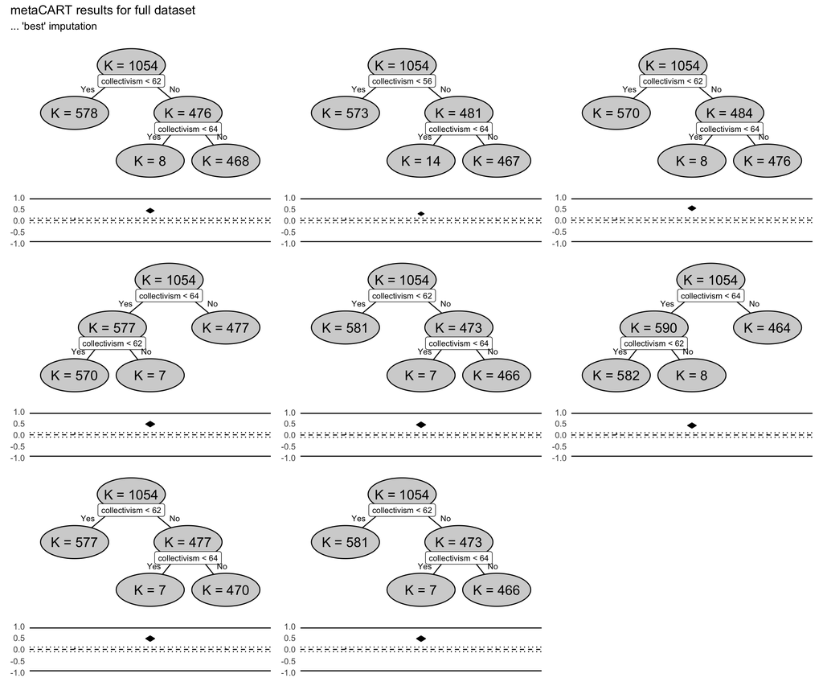

```r
wrap_plots(ps_best) + plot_annotation(title = "metaCART results for full dataset", subtitle = "... 'best' imputation")
```

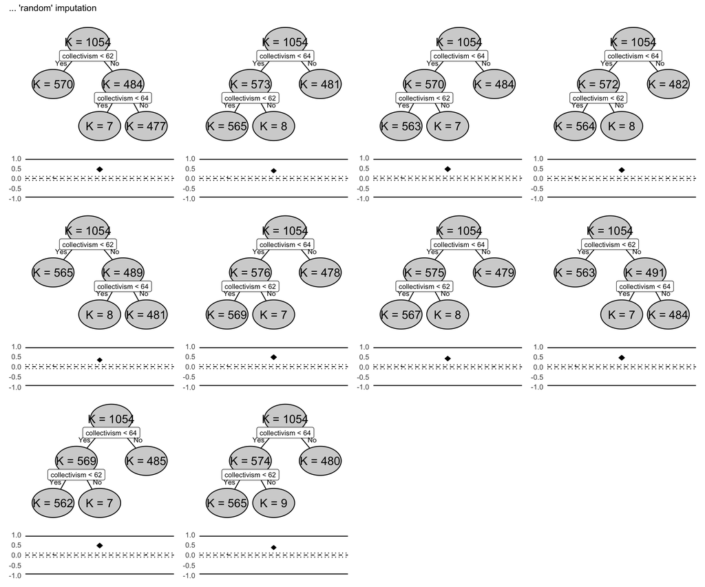

```r
wrap_plots(ps_rand) + plot_annotation(subtitle = "... 'random' imputation")
```

Overall, these models reliably picks out a small cluster of countries (Turkey, United Arab Emirates and Kuwait, though 5/7 studies with observed collectivism in the 62-63 range are from Turkey). These studies obviously differ from others based on other moderators as well - the following table shows their values on all moderators, so that the reader can decide how to interpret the finding that they have a substantially greater correlation.

```r
dataset %>% filter(collectivism > 61 & collectivism < 64) %>% group_by(id) %>% slice_head(n=1) %>% ungroup() %>% select(author_year, country, all_of(c(cat_moderators, cont_moderators, expl_mods)), -country_grp) %>%
  DT::datatable(options = list(scrollX = TRUE, lengthChange = FALSE, searching = FALSE, paging = FALSE)
)
```

|  | author_year | country | complexity | interdep | longevity | meas_type | rater | design | art_focus | year_merged | collectivism | power_distance | tmt | stud_sample | ind_sector | team_function | domain_and_sub | objective_rater |
| --- | --- | --- | --- | --- | --- | --- | --- | --- | --- | --- | --- | --- | --- | --- | --- | --- | --- | --- |
| 1 | Dayan &amp; Di Benedetto (2010) | Turkey | high | high |  | Variety | Subjective - supervisor | Observational | focal H | 2010 | 63 | 66 | no | no | Multiple/mixed | R &amp; D / Research | Job-related function | Subjective |
| 2 | Dayan et al. (2017) | Turkey | high | high |  | Variety | Subjective - supervisor | Observational | auxiliary H | 2017 | 63 | 66 | no | no | Manufacturing | R &amp; D / Research | Job-related function | Subjective |
| 3 | Mohammed &amp; Amjad (2011) | United Arab Emirates | low | medium |  | Variety | Subjective - supervisor | Observational | focal H | 2011 | 62 | 80 | no | no | Other | Production/manual work | Demographic nationality | Subjective |
| 4 | Dayan (2012) | Turkey | high | high | stable | Variety | Subjective - supervisor | Observational | auxiliary H | 2012 | 63 | 66 | no | no | Manufacturing | R &amp; D / Research | Job-related function | Subjective |
| 5 | Aşıkgoz et al. (2016) | Turkey | high | high |  | Variety | Subjective - self | Observational | focal H | 2016 | 63 | 66 | no | no | High Tech | R &amp; D / Research | Job-related other | Subjective |
| 6 | Altiner &amp; Ayhan (2018) | Turkey | high | high | stable | Separation | Objective | Observational | focal H | 2018 | 63 | 66 | no | no | Banking | Software development | Demographic age | Objective |
| 7 | Alabduljader (2018) | Kuwait | high | high | years | Variety | Objective | Observational | auxiliary H | 2017 | 62 | 80 | yes | no | Multiple/mixed | Management | Cognitive degree | Objective |

```r
rand_Job <- trees[which(str_detect(names(trees), "rand_Job.*_ahead"))] %>% list_flatten()

which_3_leaves <- which(sapply(rand_Job, \(x) length(x$n) == 3))

moderators <- rand_Job[which_3_leaves] %>% map("moderators") %>% map_chr(~paste(collapse = " | ", .))

table(moderators)[1] %>% {glue::glue("Most frequent moderator combination for 'rand' imputation of job-related dataset: {names(.)} occurred {.} times (out of 500 runs).")}
```

```
## Most frequent moderator combination for 'rand' imputation of job-related dataset: collectivism occurred 186 times (out of 500 runs).
```

```r
which_collectivism <- which(moderators == "collectivism")

mods_rand <- rand_Job[which_3_leaves][which_collectivism] %>%
  enframe(name = "names", value = "data") %>%
  separate(names, into = c(NA, NA, "dataset", NA, NA), sep = "_") %>%
  group_by(dataset) %>%
  slice_head(n = 1) %>%
  ungroup() %>%
  pull(data)

best_Job <- trees[which(str_detect(names(trees), "best_Job.*_ahead"))] %>% list_flatten()

which_3_leaves <- which(sapply(best_Job, \(x) length(x$n) == 3))

moderators <- best_Job[which_3_leaves] %>% map("moderators") %>% map_chr(~paste(collapse = " | ", .))

table(moderators)[1] %>% {glue::glue("Most frequent moderator combination for 'rand' imputation of job-related dataset: {names(.)} occurred {.} times (out of 500 runs).")}
```

```
## Most frequent moderator combination for 'rand' imputation of job-related dataset: collectivism occurred 80 times (out of 500 runs).
```

```r
which_collectivism <- which(moderators == "collectivism")

mods_best <- best_Job[which_3_leaves][which_collectivism] %>%
  enframe(name = "names", value = "data") %>%
  separate(names, into = c(NA, NA, "dataset", NA, NA), sep = "_") %>%
  group_by(dataset) %>%
  slice_head(n = 1) %>%
  ungroup() %>%
  pull(data)
```

```r
ps_rand <- map(mods_rand, metacart_plot)
ps_best <- map(mods_best, metacart_plot)
```

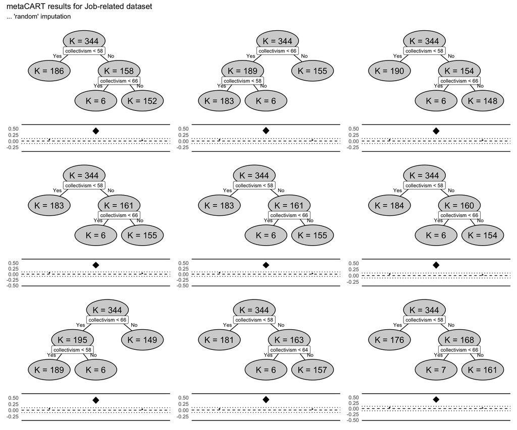

```r
wrap_plots(ps_rand) + plot_annotation(title = "metaCART results for Job-related dataset", subtitle = "... 'random' imputation")
```

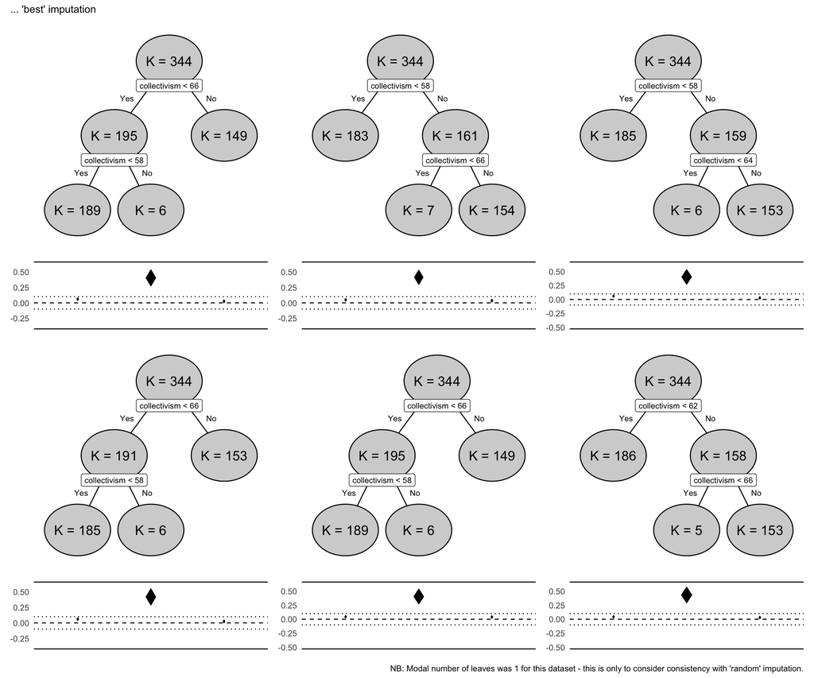

```r
wrap_plots(ps_best) + plot_annotation(subtitle = "... 'best' imputation", caption = "NB: Modal number of leaves was 1 for this dataset - this is only to consider consistency with 'random' imputation.")
```